# Comparison of Employee Benefits in India and Turkey

Let's start by reviewing the number of locations and employees in each country.

|  | Country | Location | Count |
| --- | --- | --- | --- |
| 1 | India | A1_1 | 671 |
| 2 | Turkey | B1_1 | 35 |

The data includes one location from India and one from Turkey. **The number of employees in India is significantly higher — nearly 19 times more**. Now let's move on to comparing the overall figures for each location.

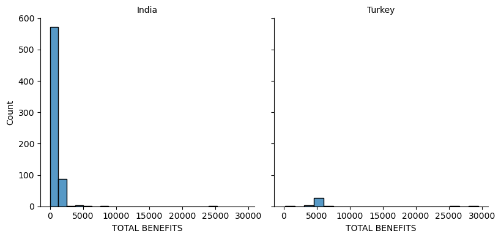

As seen in the charts, most employees in India receive relatively small benefit amounts, while in Turkey, the majority of employees receive higher payouts. It’s also noticeable that a small group of individuals receives significantly more benefits than most workers. Let’s check if the data contains any statistical outliers.

|  | Country | Location | Actual position | TOTAL BENEFITS |
| --- | --- | --- | --- | --- |
| 680 | Turkey | B1_1 | HR Director | 29493.029197 |
| 679 | Turkey | B1_1 | Administrative Director | 26174.197080 |
| 651 | India | A1_1 | Manager | 25283.855422 |
| 273 | India | A1_1 | Country Manager | 24607.626506 |
| 270 | India | A1_1 | Air Support Manager | 8559.000000 |
| 678 | Turkey | B1_1 | Accounting & Tax Manager | 7340.328467 |

According to the data, **four employees receive significantly more benefits than the rest**. The values then decrease gradually when sorted from highest to lowest.

Two of these employees are expatriates from India, which likely explains their high benefits. The other two are employees from Turkey, whose benefits are largely tied to car expense compensation.

All Data

|  | TOTAL BENEFITS |
| --- | --- |
| count | 706.000000 |
| mean | 691.142635 |
| std | 2269.075683 |
| min | 0.000000 |
| 25% | 73.144578 |
| 50% | 73.144578 |
| 75% | 113.180723 |
| max | 29493.029197 |

Excluding Top-4

|  | TOTAL BENEFITS |
| --- | --- |
| count | 702.000000 |
| mean | 544.712240 |
| std | 1169.665326 |
| min | 0.000000 |
| 25% | 73.144578 |
| 50% | 73.144578 |
| 75% | 113.180723 |
| max | 8559.000000 |

Next, we will examine the total benefit costs by country and the average per employee.

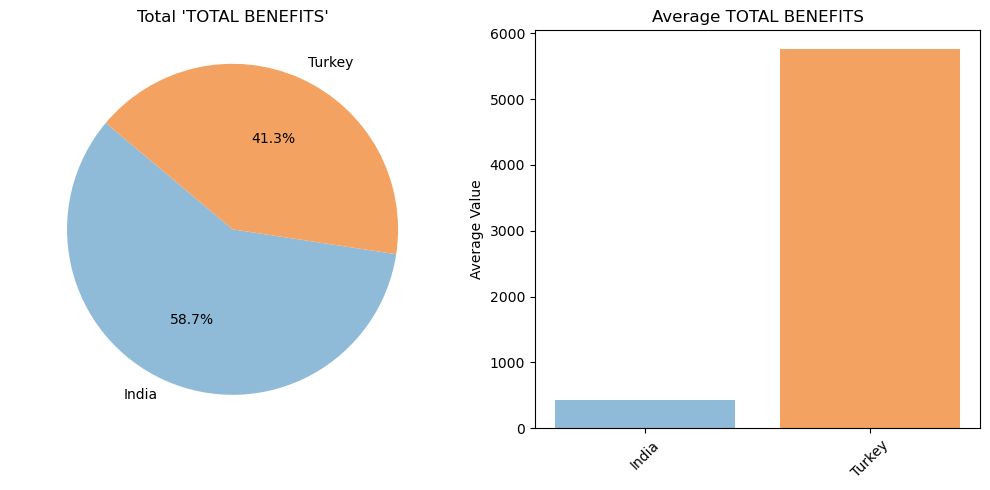

Due to the large number of employees, the overall benefit costs in India are higher. However, **on average, one employee in Turkey receives 13.49 times more in benefits** than one in India. This may indicate either higher-level roles in Turkey or a substantial imbalance in benefit distribution between the countries. Let’s now compare identical roles across both countries. **Turkey has 11 roles, 7 of which also exist in India**.

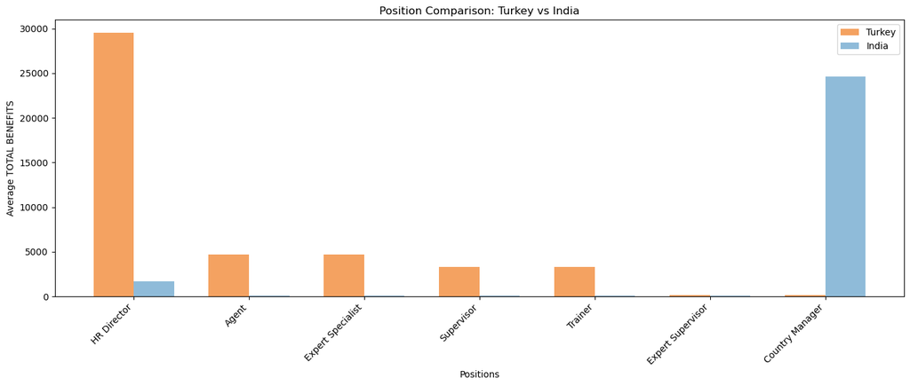

The comparison shows a noticeable shift toward higher benefit spending in Turkey, except for one role — Country Manager. In both countries, there is one person in this role, but in India, it is an expatriate, which explains the higher cost. This situation highlights the lack of a unified compensation policy across countries and roles.

To draw final conclusions, let’s look at benefit spending by role. The dataset includes **75 roles** across the two countries. For easier visualization, let’s focus on the **top 10 roles, which account for 71.63% of the total costs**.

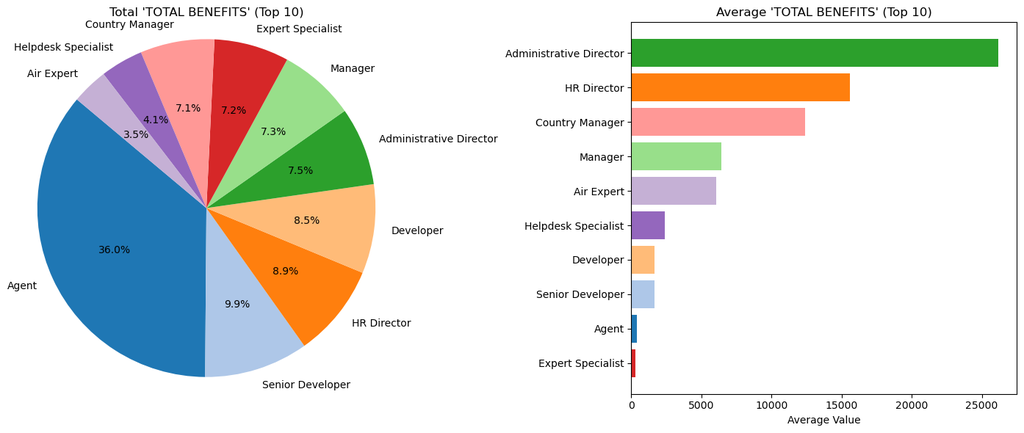

We’ll now examine the average benefit amounts per role across both countries to understand how payouts are distributed among positions.

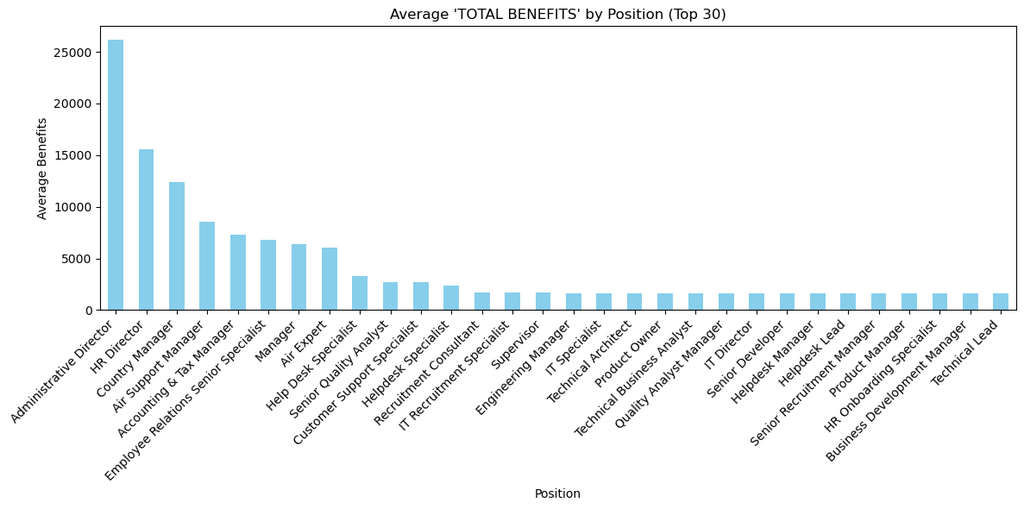

**Out of the 75 roles, the top 8 (~11% of all roles) by average benefit level account for about 60% of the total benefit amount**, based on the average values per role. Four employees receiving abnormally high benefits fall within these eight roles, likely having a significant impact on the overall share.

## Executive Summary

### 📌 1. Establish fair compensation boundaries by role, not by country

The charts show that the company pays different benefit amounts for the same role depending on the country. Instead of focusing solely on location, it's better to set global compensation frameworks for each role, adjusting for economic conditions using purchasing power indices — such as the Purchasing Power Index (Numbeo) or World Bank PLI.

This is important for:

🤝 Fairness among employees  
🚀 Motivation and retention  
🧩 Transparency and predictability in HR policy

With the rise of remote work and global hiring, relying solely on "local rates" is becoming outdated.

### 📌 2. Verify the justification for the concentration of benefits in a limited number of roles

Out of 75 roles, the top 8 (~11%) by average benefit level account for around 60% of the total benefit amount, based on average role values. This may reflect the company’s hierarchical structure. In addition, four employees with abnormally high benefits significantly influence the statistics, but such concentration in the top 8 roles requires further scrutiny regarding:

📊 Alignment of role and cost level  
🧾 Fairness and market competitiveness of compensation

A further audit is recommended: analyze the business value of these roles and compare their compensation levels to market benchmarks using public sources such as Glassdoor, PayScale, or Mercer reports.

### 📌 3. Assess the impact of benefits on employee retention

It is recommended to analyze how benefits affect employee turnover. Comparing benefit levels with retention trends can help assess the effectiveness of the benefits package as a retention tool.

### 📌 4. Gradual alignment of compensation policy

A strategy should be developed to gradually align approaches to benefits:

📈 In countries with low payouts — gradual increases  
📉 In countries with excessive costs — optimization without losing appeal

It is recommended to start with the top 10 roles by benefit volume, as this is where:

1. the biggest imbalances are likely (underpayment or overpayment),
2. the bulk of the costs lies.